# Distribuciones Discretas II

# Distribución Hipergeométrica

- Esta distribución está sujeta a condiciones de **muestreo sin reemplazo** en las que cada elemento es diferente y será elegido hasta completar la muestra, sin restituir los elementos extraídos.
- El tamaño de la población del cual proviene la muestra es conocido.
- Permite responder a la probabilidad de obtener $k$ éxitos en una muestra con $n$ elementos, proveniente de una población de tamaño $N$.

Una variable aleatoria $X$ tiene distribución Hipergeométrica si su función de densidad es:
$$f(x) = \frac{\binom{k}{x} \binom{N-k}{n-x}}{\binom{N}{n}};\ x = 0, 1, ..., k$$

donde:

- *N*: tamaño de la población
- *n*: tamaño de la muestra extraída
- *k*: número de elementos en la población original que pertenecen al evento deseado
- *x*: número de elementos en la muestra que pertenecen al evento deseado

Notación:
$$X \sim h(n, k, N)$$

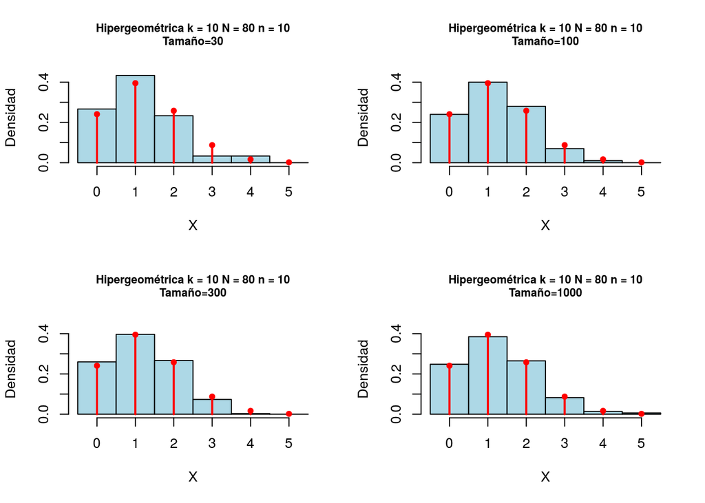

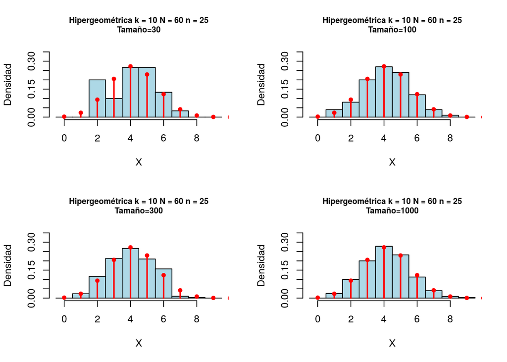

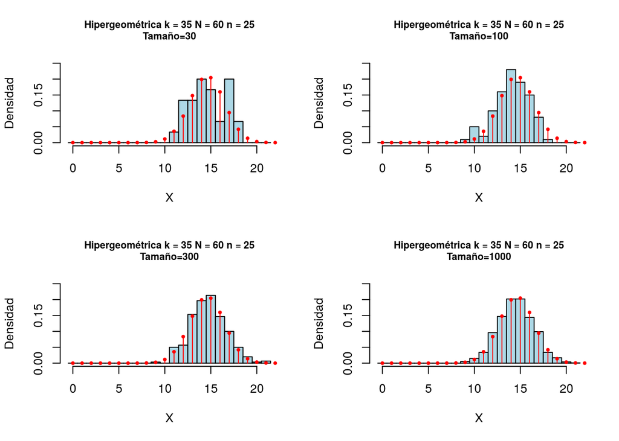

## Esperanza ($E[X]$) y varianza ($Var[X]$)

- $E[X] = np$
- $Var[X] = np(1-p) \frac{N-n}{N-1}$

Donde:

- $p = \frac{k}{N}$
- $\frac{N-n}{N-1}$: es el factor de corrección para poblaciones finitas

## Ejemplo

Un lote de bovinos contiene 100 animales alimentados con la dieta A y 200 animales alimentados con la dieta B. Si se escogen 4 animales al azar, sin reemplazo. Obtener:

**Solución:**

- $N$: $300 = (200 + 100)$
- $n$: $4$
- $k$: 100 y 200, para la dieta A y B, respectivamente.
1. $P(X = 4) = \frac{\binom{100}{4} \binom{300-100}{0}}{\binom{300}{4}} = 0.0119$
2. $P(X \geq 2) = \frac{\binom{100}{2} \binom{300-100}{2}}{\binom{300}{4}} + \frac{\binom{100}{3} \binom{300-100}{3}}{\binom{300}{4}} + \frac{\binom{100}{4} \binom{300-100}{0}}{\binom{300}{4}} = 0.408$

Funciones importantes:

- `rhyper()`: generar números bajo la distribución Hipergeométrica
- `dhyper()`: función masa de probabilidad
- `phyper()`: función de distribución acumulada

```r
#P(X = 4)
dhyper(x = 4, m = 100, n = 200, k = 4)
```

```
## [1] 0.01185408
```

```r
#P(X >= 2)
sum(dhyper(x = 2:4, m = 100, n = 200, k = 4))
```

```
## [1] 0.4074057
```

```r
1 - phyper(q = 1, m = 100, n = 200, k = 4) #P(X >= 2)
```

```
## [1] 0.4074057
```

```r
phyper(q = 1, m = 100, n = 200, k = 4, lower.tail = F) #P(X >= 2)
```

```
## [1] 0.4074057
```